# Two Sample T-Test

Author

Bill Perry

# Introduction to Two-Sample t-Test

## Background and Theory

The two-sample t-test (also known as independent samples t-test) is used to determine whether there is a statistically significant difference between the means of two independent groups. In this analysis, we will examine whether there are significant differences in the total length of slimy sculpin fish between two different lakes.

The two-sample t-test makes the following comparison:

$$H_0: \mu_1 = \mu_2$$
$$H_A: \mu_1 \neq \mu_2$$

Where: - $H_0$ is the null hypothesis stating that the population means are equal - $H_A$ is the alternative hypothesis stating that the population means are different - $\mu_1$ is the population mean of the first group - $\mu_2$ is the population mean of the second group

## Formula

The formula for the two-sample t-test with equal variances (pooled variance) is:

$$t = \frac{\bar{x}_1 - \bar{x}_2}{s_p \sqrt{\frac{1}{n_1} + \frac{1}{n_2}}}$$

Where: - $\bar{x}_1$ is the sample mean of the first group - $\bar{x}_2$ is the sample mean of the second group - $s_p$ is the pooled standard deviation - $n_1$ is the sample size of the first group - $n_2$ is the sample size of the second group

The pooled standard deviation is calculated as:

$$s_p = \sqrt{\frac{(n_1-1)s_1^2 + (n_2-1)s_2^2}{n_1 + n_2 - 2}}$$

Where: - $s_1^2$ is the variance of the first group - $s_2^2$ is the variance of the second group

The degrees of freedom (df) for this test is $n_1 + n_2 - 2$.

For unequal variances (Welch’s t-test), the formula is slightly different:

$$t = \frac{\bar{x}_1 - \bar{x}_2}{\sqrt{\frac{s_1^2}{n_1} + \frac{s_2^2}{n_2}}}$$

With degrees of freedom approximated using the Welch-Satterthwaite equation:

$$df = \frac{(\frac{s_1^2}{n_1} + \frac{s_2^2}{n_2})^2}{\frac{(s_1^2/n_1)^2}{n_1-1} + \frac{(s_2^2/n_2)^2}{n_2-1}}$$

# Data Analysis

## Loading Libraries and Data

```r
# Load required libraries
library(tidyverse)
library(car)  # For Levene's test
# library(ggpubr)  # For adding p-values to plots
library(coin)  # For permutation tests
library(rcompanion)  # For plotNormalHistogram

# Load the data
sculpin_data <- read_csv("data/sculpin.csv")
# Preview the data
head(sculpin_data)
```

```
# A tibble: 6 × 5
   site lake  species       length_mm mass_g
  <dbl> <chr> <chr>             <dbl>  <dbl>
1   146 E 01  slimy sculpin        53   1.25
2   146 E 01  slimy sculpin        61   1.9
3   146 E 01  slimy sculpin        53   1.75
4   146 E 01  slimy sculpin        77   4.25
5   146 E 01  slimy sculpin        45   0.9
6   146 E 01  slimy sculpin        48   0.9
```

## Data Overview

Let’s first examine the structure of our dataset:

```r
# Structure of the dataset
str(sculpin_data)
```

```
spc_tbl_ [1,052 × 5] (S3: spec_tbl_df/tbl_df/tbl/data.frame)
 $ site     : num [1:1052] 146 146 146 146 146 146 146 146 146 146 ...
 $ lake     : chr [1:1052] "E 01" "E 01" "E 01" "E 01" ...
 $ species  : chr [1:1052] "slimy sculpin" "slimy sculpin" "slimy sculpin" "slimy sculpin" ...
 $ length_mm: num [1:1052] 53 61 53 77 45 48 51 57 51 56 ...
 $ mass_g   : num [1:1052] 1.25 1.9 1.75 4.25 0.9 0.9 1.05 1.15 1.15 1.3 ...
 - attr(*, "spec")=
  .. cols(
  ..   site = col_double(),
  ..   lake = col_character(),
  ..   species = col_character(),
  ..   length_mm = col_double(),
  ..   mass_g = col_double()
  .. )
 - attr(*, "problems")=<externalptr>
```

```r
# Summary statistics
summary(sculpin_data)
```

```
      site           lake             species            length_mm
 Min.   :100.0   Length:1052        Length:1052        Min.   : 11.00
 1st Qu.:107.0   Class :character   Class :character   1st Qu.: 44.00
 Median :108.0   Mode  :character   Mode  :character   Median : 52.00
 Mean   :121.8                                         Mean   : 52.44
 3rd Qu.:141.0                                         3rd Qu.: 60.00
 Max.   :152.0                                         Max.   :194.00
 NA's   :79                                            NA's   :329
     mass_g
 Min.   : 0.0037
 1st Qu.: 0.7000
 Median : 1.1500
 Mean   : 1.4577
 3rd Qu.: 1.7700
 Max.   :46.0000
```

```r
# Check for missing values
colSums(is.na(sculpin_data))
```

```
     site      lake   species length_mm    mass_g
       79         0         0       329         0
```

## Data Preparation

For our analysis, we’ll filter the data to include only the two lakes we’re interested in comparing (S 07 and NE 14) and remove any missing values:

```r
# Select lakes for comparison
lakes_to_compare <- c("S 07", "NE 14")

# Filter data
sculpin_filtered <- sculpin_data %>%
  filter(lake %in% lakes_to_compare) %>%
  filter(!is.na(length_mm))

# Create individual datasets for each lake
s07_data <- sculpin_filtered %>% filter(lake == "S 07")
ne14_data <- sculpin_filtered %>% filter(lake == "NE 14")

# Check the number of observations per lake
sculpin_filtered %>%
  group_by(lake) %>%
  summarize(
    count = n(),
    mean_length = mean(length_mm),
    sd_length = sd(length_mm),
    se_length = sd_length / sqrt(count)
  )
```

```
# A tibble: 2 × 5
  lake  count mean_length sd_length se_length
  <chr> <int>       <dbl>     <dbl>     <dbl>
1 NE 14    37        47.3      10.5      1.72
2 S 07     73        55.6      12.7      1.48
```

## Data Visualization

### Box Plot with Individual Data Points

Let’s create a box plot with individual data points to visualize the distribution of total length in the two lakes:

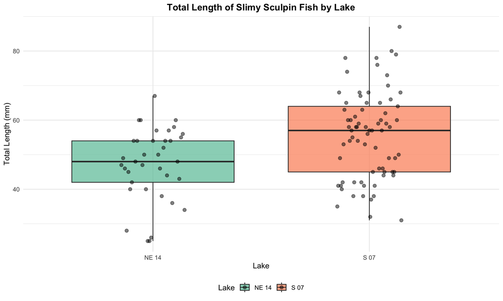

```r
# Create boxplot with individual points
ggplot(sculpin_filtered, aes(x = lake, y = length_mm, fill = lake)) +
  geom_boxplot(alpha = 0.7, outlier.shape = NA) +
  geom_point(position = position_dodge2(width = 0.3),
             alpha = 0.5, size = 2) +
  labs(
    title = "Total Length of Slimy Sculpin Fish by Lake",
    x = "Lake",
    y = "Total Length (mm)",
    fill = "Lake"
  ) +
  theme_minimal() +
  theme(
    plot.title = element_text(hjust = 0.5, face = "bold"),
    legend.position = "bottom"
  ) +
  scale_fill_brewer(palette = "Set2")
```

### Mean and Standard Error Plot

Now, let’s create a plot showing the mean and standard error for each lake, with individual data points in the background:

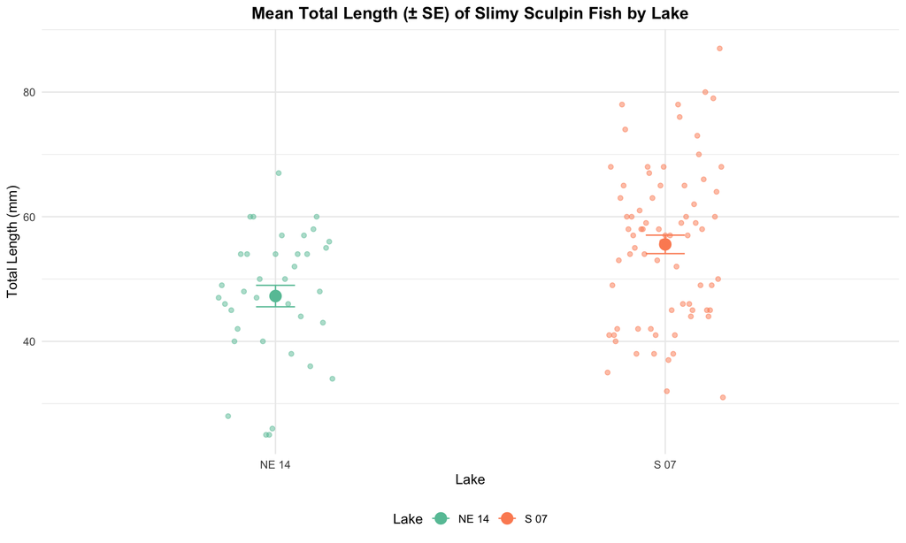

```r
# Create mean and standard error plot with data points
ggplot(sculpin_filtered, aes(x = lake, y = length_mm, color = lake)) +
  # Add individual data points in the background
  geom_point(position = position_dodge2(width = 0.3),
             alpha = 0.5, size = 1.5) +
  # Add mean and standard error
  stat_summary(fun = mean, geom = "point", size = 4) +
  stat_summary(fun.data = mean_se, geom = "errorbar", width = 0.1) +
  labs(
    title = "Mean Total Length (± SE) of Slimy Sculpin Fish by Lake",
    x = "Lake",
    y = "Total Length (mm)",
    color = "Lake"
  ) +
  theme_minimal() +
  theme(
    plot.title = element_text(hjust = 0.5, face = "bold"),
    legend.position = "bottom"
  ) +
  scale_color_brewer(palette = "Set2")
```

# Testing t-Test Assumptions

Before conducting the t-test, we need to verify that our data meets the underlying assumptions:

## Assumptions of the Two-Sample t-Test

1. **Independence**: The observations within each group are independent, and the two groups are independent of each other.
2. **Normality**: The data in each group follow a normal distribution.
3. **Homogeneity of Variances**: The variances of the two groups are approximately equal (for the standard t-test).

Let’s test each of these assumptions:

### 1. Independence Assumption

Independence is a design issue and can’t be tested statistically. We assume our sampling design ensures independence between and within groups.

### 2. Normality Assumption

We’ll check normality using: - Histograms - Q-Q plots - Shapiro-Wilk test

#### Histograms

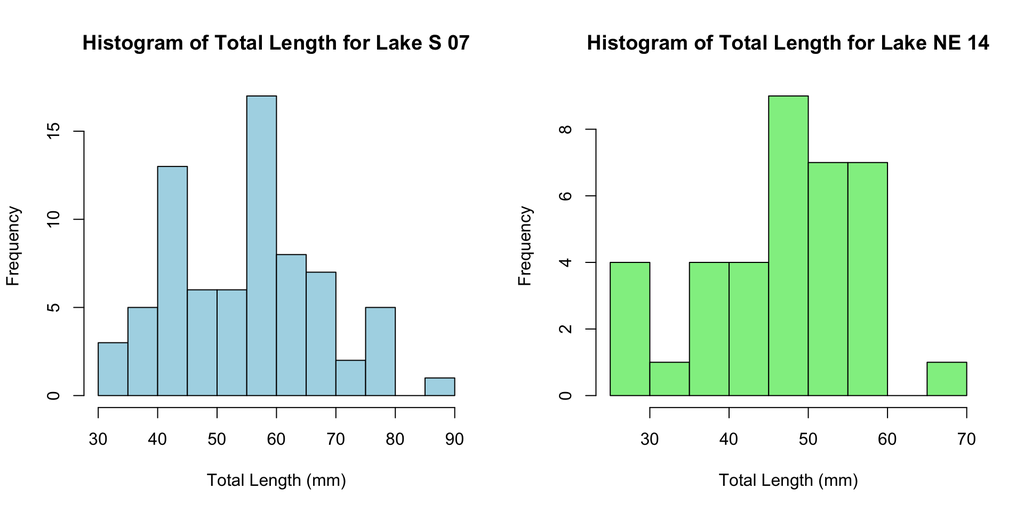

```r
# Create histograms for both lakes
par(mfrow = c(1, 2))

# Lake S 07
hist(s07_data$length_mm,
     main = "Histogram of Total Length for Lake S 07",
     xlab = "Total Length (mm)",
     col = "lightblue",
     breaks = 10)

# Lake NE 14
hist(ne14_data$length_mm,
     main = "Histogram of Total Length for Lake NE 14",
     xlab = "Total Length (mm)",
     col = "lightgreen",
     breaks = 8)
```

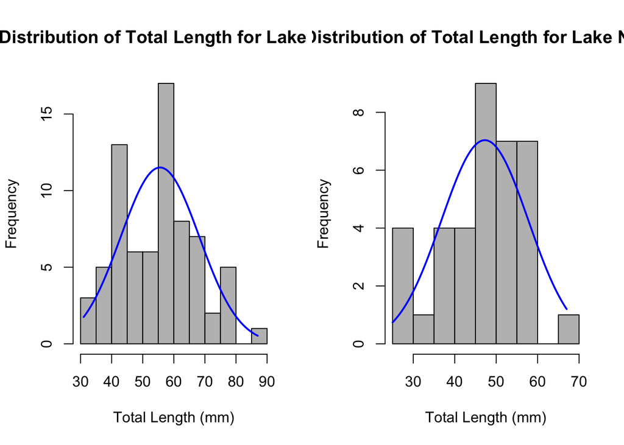

```r
# Create normal quantile plots for each lake with a normal histogram
par(mfrow = c(1, 2))

# Lake S 07
plotNormalHistogram(s07_data$length_mm,
                    main = "Distribution of Total Length for Lake S 07",
                    xlab = "Total Length (mm)")

# Lake NE 14
plotNormalHistogram(ne14_data$length_mm,
                    main = "Distribution of Total Length for Lake NE 14",
                    xlab = "Total Length (mm)")
```

### QQ Plots

Let’s create individual QQ plots for each lake:

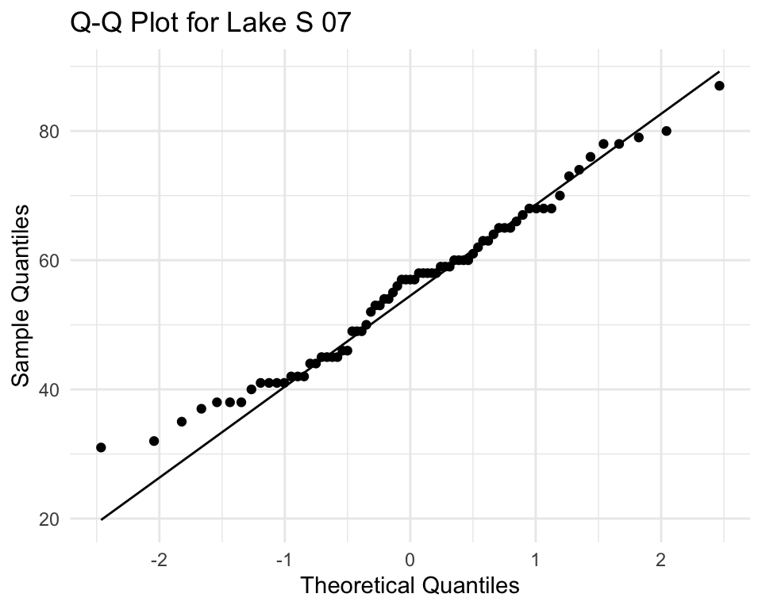

```r
# QQ plot for Lake S 07
s07_data <- sculpin_filtered %>% filter(lake == "S 07")
ggplot(data = s07_data, aes(sample = length_mm)) +
  stat_qq() +
  stat_qq_line() +
  labs(
    title = "Q-Q Plot for Lake S 07",
    x = "Theoretical Quantiles",
    y = "Sample Quantiles"
  ) +
  theme_minimal()
```

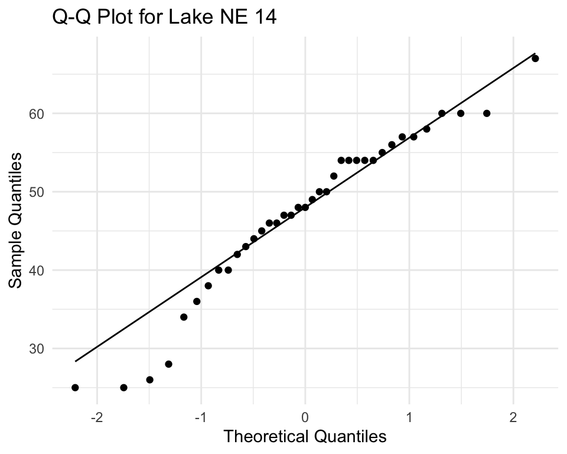

```r
# QQ plot for Lake NE 14
ne14_data <- sculpin_filtered %>% filter(lake == "NE 14")
ggplot(data = ne14_data, aes(sample = length_mm)) +
  stat_qq() +
  stat_qq_line() +
  labs(
    title = "Q-Q Plot for Lake NE 14",
    x = "Theoretical Quantiles",
    y = "Sample Quantiles"
  ) +
  theme_minimal()
```

### Shapiro-Wilk Test

```r
# Shapiro-Wilk test for Lake S 07
shapiro_s07 <- shapiro.test(s07_data$length_mm)
print("Shapiro-Wilk test for Lake S 07:")
```

```
[1] "Shapiro-Wilk test for Lake S 07:"
```

```r
print(shapiro_s07)
```

```
    Shapiro-Wilk normality test

data:  s07_data$length_mm
W = 0.98035, p-value = 0.3125
```

```r
# Shapiro-Wilk test for Lake NE 14
shapiro_ne14 <- shapiro.test(ne14_data$length_mm)
print("Shapiro-Wilk test for Lake NE 14:")
```

```
[1] "Shapiro-Wilk test for Lake NE 14:"
```

```r
print(shapiro_ne14)
```

```
    Shapiro-Wilk normality test

data:  ne14_data$length_mm
W = 0.9479, p-value = 0.08258
```

```r
# Summary table
shapiro_results <- data.frame(
  Lake = c("S 07", "NE 14"),
  W_statistic = c(shapiro_s07$statistic, shapiro_ne14$statistic),
  p_value = c(shapiro_s07$p.value, shapiro_ne14$p.value),
  is_normal = c(shapiro_s07$p.value > 0.05, shapiro_ne14$p.value > 0.05)
)

knitr::kable(shapiro_results, caption = "Shapiro-Wilk Test Results")
```

Shapiro-Wilk Test Results

| Lake | W_statistic | p_value | is_normal |
| --- | --- | --- | --- |
| S 07 | 0.9803526 | 0.3125255 | TRUE |
| NE 14 | 0.9479006 | 0.0825839 | TRUE |

### 3. Homogeneity of Variances

We’ll check for homogeneity of variances using: - Visual inspection of boxplots (already done above) - Levene’s test

```r
# Calculate variances for each group
s07_variance <- var(s07_data$length_mm)
ne14_variance <- var(ne14_data$length_mm)

# Print variances
cat("Variance for Lake S 07:", s07_variance, "\n")
```

```
Variance for Lake S 07: 160.0552
```

```r
cat("Variance for Lake NE 14:", ne14_variance, "\n")
```

```
Variance for Lake NE 14: 109.9805
```

```r
# Calculate variance ratio
variance_ratio <- max(s07_variance, ne14_variance) / min(s07_variance, ne14_variance)
cat("Variance ratio (larger/smaller):", variance_ratio, "\n")
```

```
Variance ratio (larger/smaller): 1.455305
```

```r
# Levene's test for homogeneity of variances
levene_test <- leveneTest(length_mm ~ lake, data = sculpin_filtered)
print(levene_test)
```

```
Levene's Test for Homogeneity of Variance (center = median)
       Df F value Pr(>F)
group   1   2.029 0.1572
      108
```

## Interpretation of Assumption Tests

Based on the results of our assumption tests:

1. **Independence**: We assume this is met based on the data collection process, as samples from each lake were collected independently of one another.
2. **Normality**:
   - The Q-Q plots show that the data points largely follow the theoretical normal distribution line for both lakes, with some minor deviations at the extremes.
   - The Shapiro-Wilk test results will help us formally assess normality. If the p-value is greater than 0.05, we fail to reject the null hypothesis that the data is normally distributed.
   - For samples larger than 30, the Central Limit Theorem suggests that the sampling distribution of means will be approximately normal regardless of the underlying distribution.
3. **Homogeneity of Variances**:
   - Levene’s test evaluates whether the variances between groups are equal.
   - A p-value greater than 0.05 indicates that we cannot reject the null hypothesis of equal variances.
   - As a rule of thumb, if the variance ratio is less than 4:1, the t-test is reasonably robust to violations of this assumption.
   - If this assumption is violated, we should consider using Welch’s t-test instead, which does not assume equal variances.

# Two-Sample t-Test

Now that we’ve checked the assumptions, we can perform the two-sample t-test:

```r
# Perform the t-test with equal variance (standard t-test)
t_test_equal_var <- t.test(
  length_mm ~ lake,
  data = sculpin_filtered,
  var.equal = TRUE  # Use pooled variance
)

# Display the results
print("Two-sample t-test with equal variances:")
```

```
[1] "Two-sample t-test with equal variances:"
```

```r
print(t_test_equal_var)
```

```
    Two Sample t-test

data:  length_mm by lake
t = -3.4314, df = 108, p-value = 0.0008519
alternative hypothesis: true difference in means between group NE 14 and group S 07 is not equal to 0
95 percent confidence interval:
 -13.080929  -3.501818
sample estimates:
mean in group NE 14  mean in group S 07
           47.27027            55.56164
```

```r
# For comparison, also perform Welch's t-test (unequal variances)
t_test_welch <- t.test(
  length_mm ~ lake,
  data = sculpin_filtered,
  var.equal = FALSE  # Use Welch's correction
)

print("\nWelch's t-test (unequal variances):")
```

```
[1] "\nWelch's t-test (unequal variances):"
```

```r
print(t_test_welch)
```

```
    Welch Two Sample t-test

data:  length_mm by lake
t = -3.6483, df = 85.45, p-value = 0.0004533
alternative hypothesis: true difference in means between group NE 14 and group S 07 is not equal to 0
95 percent confidence interval:
 -12.809687  -3.773061
sample estimates:
mean in group NE 14  mean in group S 07
           47.27027            55.56164
```

```r
# Extract key values for reporting
t_statistic <- round(t_test_equal_var$statistic, 2)
df <- t_test_equal_var$parameter
p_value <- t_test_equal_var$p.value
mean_diff <- round(diff(t_test_equal_var$estimate), 2)
```

## Line-by-Line Interpretation of t-Test Results

Let’s break down the t-test output:

1. **Test Type**: Two Sample t-test
2. **Formula**: `length_mm ~ lake` means we’re testing if total length differs by lake
3. **Data**: Our filtered sculpin dataset
4. **t-value**: The calculated t-statistic
5. **Degrees of Freedom (df)**: n₁ + n₂ - 2
6. **p-value**: The probability of observing this data (or more extreme) if the null hypothesis is true
7. **Alternative Hypothesis**: The means are different
8. **95% Confidence Interval**: The estimated range for the true difference in means
9. **Sample Estimates**: The means of each group

## Visual Representation of t-Test Results

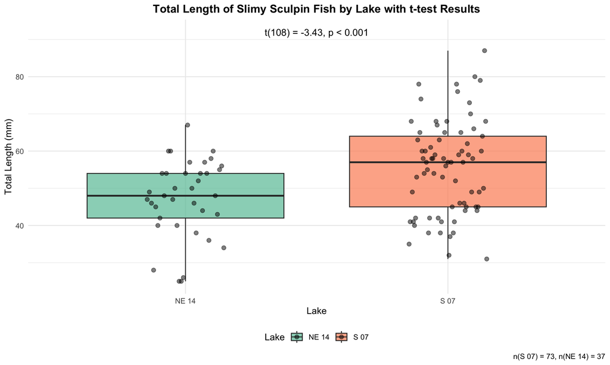

```r
# Create a plot with the t-test results
p_value_text <- ifelse(p_value < 0.001, "p < 0.001", paste("p =", round(p_value, 3)))

ggplot(sculpin_filtered, aes(x = lake, y = length_mm, fill = lake)) +
  geom_boxplot(alpha = 0.7, outlier.shape = NA) +
  geom_point(position = position_dodge2(width = 0.3),
             alpha = 0.5, size = 2) +
  annotate("text", x = 1.5, y = max(sculpin_filtered$length_mm) + 5,
           label = paste0("t(", round(df), ") = ", t_statistic, ", ", p_value_text),
           size = 4) +
  labs(
    title = "Total Length of Slimy Sculpin Fish by Lake with t-test Results",
    x = "Lake",
    y = "Total Length (mm)",
    fill = "Lake",
    caption = paste0("n(S 07) = ", nrow(s07_data), ", n(NE 14) = ", nrow(ne14_data))
  ) +
  theme_minimal() +
  theme(
    plot.title = element_text(hjust = 0.5, face = "bold"),
    legend.position = "bottom"
  ) +
  scale_fill_brewer(palette = "Set2")
```

# Conclusion and Scientific Reporting

```r
# Calculate means and standard errors for reporting
mean_se_by_lake <- sculpin_filtered %>%
  group_by(lake) %>%
  summarize(
    n = n(),
    mean = mean(length_mm),
    sd = sd(length_mm),
    se = sd / sqrt(n)
  )

print(mean_se_by_lake)
```

```
# A tibble: 2 × 5
  lake      n  mean    sd    se
  <chr> <int> <dbl> <dbl> <dbl>
1 NE 14    37  47.3  10.5  1.72
2 S 07     73  55.6  12.7  1.48
```

```r
# Calculate percent difference
percent_diff <- abs(diff(mean_se_by_lake$mean)) / min(mean_se_by_lake$mean) * 100
```

Based on our analysis, we can conclude:

The total length of slimy sculpin fish differs significantly between Lake S 07 and Lake NE 14 (two-sample t-test: t(108) = -3.43, p < 0.001). Fish from Lake S 07 were on average 8.29 mm longer than those from Lake NE 14 (mean ± SE: 55.56 ± 1.48 mm vs. 47.27 ± 1.72 mm).

## How to Report These Results in a Scientific Publication

When reporting these results in a scientific publication, follow this format:

“Slimy sculpin (*Cottus cognatus*) from Lake S 07 were significantly larger than those from Lake NE 14

(55.56 ± 1.48 mm vs. 47.27 ± 1.72 mm, respectively; two-sample t-test: t(108) = -3.43, p < 0.001). This represents an approximately 17.5% difference in total length between the two populations.”

For figures, include:

1. A boxplot or mean/SE plot showing the difference
2. Clear labels and scales
3. Sample sizes
4. Statistical test information in the figure caption

Note I would also add the mean and SE of each lake

Back to top